# VLM Wrong Predictions: attr_abutment_material [vlm_only]

Asset 65609 3 images

Predicted: VLM: Concrete | DINOv3: Steel (conf: N/A)

Actual: Concrete

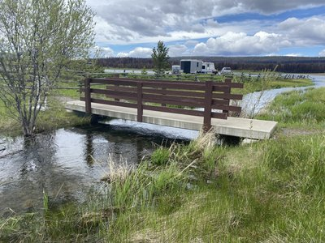

45623__IMG_0185.JPG

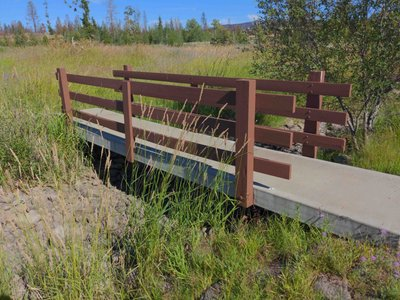

58058__MI_20220806_163737.jpg

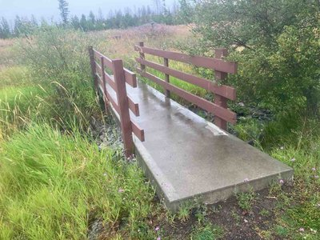

86901__AST_EX_20250815_135754.jpeg

Asset 67205 4 images

Predicted: VLM: Concrete | DINOv3: Steel (conf: N/A)

Actual: Concrete

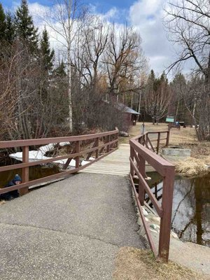

38565__AST_EX_20220331_144231.jpeg

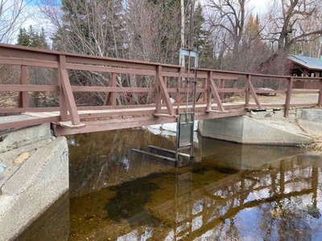

38570__AST_EX_20220331_144247.jpeg

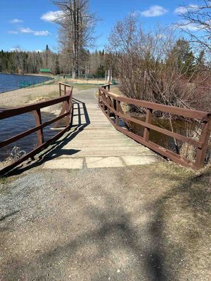

93110__AST_EX_20260422_114842.jpeg

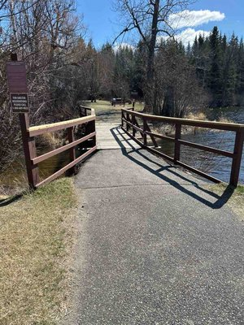

93111__AST_EX_20260422_114908.jpeg

Asset 85208 1 image

Predicted: VLM: Timber | DINOv3: Concrete (conf: N/A)

Actual: Timber

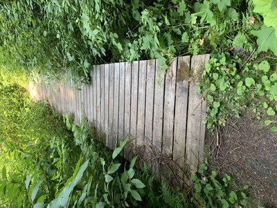

11472__AST_IM_20210804_123629.jpeg

Asset 85487 1 image

Predicted: VLM: Timber | DINOv3: Concrete (conf: N/A)

Actual: Timber

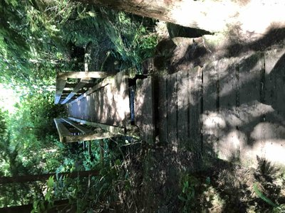

12421__AST_IM_20210804_110253.jpeg